# Load Data

```python
import pandas as pd

# Read data from CSV files
Customer_Profile = pd.read_csv('https://storage.googleapis.com/datalynn-datasets/interview-challenge/finance/Accenture_2/Customer_Profile.csv')
Billing_Data = pd.read_csv('https://storage.googleapis.com/datalynn-datasets/interview-challenge/finance/Accenture_2/Billing_Data.csv')
Customer_Service_Records = pd.read_csv('https://storage.googleapis.com/datalynn-datasets/interview-challenge/finance/Accenture_2/Customer_Service_Records.csv')
Market_Trends = pd.read_csv('https://storage.googleapis.com/datalynn-datasets/interview-challenge/finance/Accenture_2/Market_Trends.csv')
```

```python
import sqlite3
import pandas as pd
from dateutil.parser import parse

# Load datasets into SQLite database
conn = sqlite3.connect('telecom_data.db')
Customer_Profile.to_sql('Customer_Profile', conn, if_exists='replace', index=False)
Billing_Data.to_sql('Billing_Data', conn, if_exists='replace', index=False)
Customer_Service_Records.to_sql('Customer_Service_Records', conn, if_exists='replace', index=False)
Market_Trends.to_sql('Market_Trends', conn, if_exists='replace', index=False)
```

```
1000
```

## Question 1: "Identification of Churn Indicators"

Utilizing the 'Customer_Profile', 'Billing_Data', and 'Customer_Service_Records' tables, extract key indicators that could potentially signal customer churn. Describe the peculiarities you might expect in each churn signal group.

### Solution

**Hints & Explanations**

1. **Tables Involved**: 'Customer_Profile', 'Billing_Data', 'Customer_Service_Records'.
2. **Key Indicators for Churn**:
   - From `Customer_Service_Records`: Average total and unresolved complaints.
   - From `Billing_Data`: Average late payments.
   - From `Customer_Profile`: Average tenure.
3. **Joining Tables**:
   - JOIN `Customer_Profile` with both `Billing_Data` and `Customer_Service_Records` using `Customer_ID`.
4. **Grouping**: Group results by the 'Churn' column.
5. **Execute the Query**: Use the `pd.read_sql_query()` to run the SQL query.
6. **Output**: The result variable stores the desired output.

```python
query = """
SELECT
    c.Churn,
    AVG(cs.Total_Complaints) AS Avg_Total_Complaints,
    AVG(cs.Unresolved_Complaints) AS Avg_Unresolved_Complaints,
    AVG(b.Late_Payments) AS Avg_Late_Payments,
    AVG(c.Tenure) AS Avg_Tenure
FROM
    Customer_Profile c
JOIN
    Billing_Data b ON c.Customer_ID = b.Customer_ID
JOIN
    Customer_Service_Records cs ON c.Customer_ID = cs.Customer_ID
GROUP BY
    c.Churn;
"""

result = pd.read_sql_query(query, conn)
result
```

|  | Churn | Avg_Total_Complaints | Avg_Unresolved_Complaints | Avg_Late_Payments | Avg_Tenure |
| --- | --- | --- | --- | --- | --- |
| 0 | No | 4.948363 | 2.540302 | 1.965995 | 34.984887 |
| 1 | Yes | 7.781553 | 3.966019 | 3.975728 | 37.577670 |

## Question 2: Analysis of Churn Indicators Across Different Customer Segments (Python)

Using Python, identify patterns in the churn indicators across different customer demographics like age, location, or subscription type. Explain how your findings could refine the understanding of customer churn across different segments.

### Solution

**Hints & Explanations**

We can analyze churn indicators across different customer segments (e.g., by location, age, and subscription type).

```python
# Merging Dataframes
df = pd.merge(Customer_Profile, Billing_Data, on='Customer_ID')
df = pd.merge(df, Customer_Service_Records, on='Customer_ID')

# Group by location, age and subscription type
churn_by_segments = df.groupby(['Location', 'Age', 'Subscription_Type', 'Churn']).agg({'Customer_ID':'count'}).reset_index()
print(churn_by_segments)
```

```
    Location  Age Subscription_Type Churn  Customer_ID
0    Alabama   20            Plan_B    No            1
1    Alabama   21            Plan_A    No            1
2    Alabama   25            Plan_B    No            2
3    Alabama   26            Plan_B    No            1
4    Alabama   28            Plan_B    No            1
..       ...  ...               ...   ...          ...
930  Wyoming   53            Plan_A    No            1
931  Wyoming   55            Plan_B    No            1
932  Wyoming   60            Plan_B    No            1
933  Wyoming   61            Plan_B    No            1
934  Wyoming   68            Plan_A    No            2

[935 rows x 5 columns]
```

Handling sparse data: If a certain segment has sparse data, we might need to group categories together or treat them as a separate "Other" category. The key is to ensure we don't make inferences on segments where the sample size is too small to be statistically significant.

## Question 3: Investigation of the Impact of Complaint Resolution on Churn in High-Tenure Customers

Assume that you've noticed a higher churn rate amongst high-tenure customers who have unresolved complaints. Using Python, perform an analysis to confirm if unresolved complaints significantly influence the churn rate in high-tenure customers compared to those with resolved complaints.

### Solution

**Hints & Explanations**

1. Merge the datasets `Customer_Profile` and `Customer_Service_Records` based on 'Customer_ID'.
2. Filter out high-tenure customers, defining them as those with a tenure greater than the average tenure.
3. For the filtered high-tenure customers:
   - Calculate the churn rate among those with unresolved complaints.
   - Calculate the churn rate among those without unresolved complaints.
4. Display the calculated churn rates for both groups.

```python
# Merge Customer_Profile and Customer_Service_Records on 'Customer_ID'
merged_data = pd.merge(Customer_Profile, Customer_Service_Records, on='Customer_ID')

# Filter for high-tenure customers
avg_tenure = merged_data['Tenure'].mean()
high_tenure_customers = merged_data[merged_data['Tenure'] > avg_tenure]

# Calculate churn rate for high-tenure customers with unresolved complaints
high_tenure_unresolved_complaints = high_tenure_customers[high_tenure_customers['Unresolved_Complaints'] > 0]
churn_rate_unresolved_complaints = high_tenure_unresolved_complaints['Churn'].value_counts(normalize=True)['Yes']

# Calculate churn rate for high-tenure customers with no unresolved complaints
high_tenure_resolved_complaints = high_tenure_customers[high_tenure_customers['Unresolved_Complaints'] == 0]
churn_rate_resolved_complaints = high_tenure_resolved_complaints['Churn'].value_counts(normalize=True)['Yes']

print(f"Churn rate for high-tenure customers with unresolved complaints: {churn_rate_unresolved_complaints}")
print(f"Churn rate for high-tenure customers with no unresolved complaints: {churn_rate_resolved_complaints}")
```

```
Churn rate for high-tenure customers with unresolved complaints: 0.2336448598130841
Churn rate for high-tenure customers with no unresolved complaints: 0.19753086419753085
```

Based on the churn rates obtained from this analysis, if high-tenure customers with unresolved complaints indeed have a significantly higher churn rate, it would suggest that improving complaint resolution might be an effective strategy for reducing churn in this customer segment.

A potential action plan could be to introduce a priority support program specifically for high-tenure customers. The service team could be alerted to resolve complaints from these customers as quickly as possible. Additionally, regular follow-ups can be conducted to ensure their issues are fully resolved and they are satisfied with the service. This proactive approach might help improve customer satisfaction, leading to a reduction in churn rate.

Also, it is important to track the effectiveness of these measures by monitoring the churn rate of this segment over time after implementing the changes.

## Question 4: Creating Customer Interaction Graphs

Using Python, construct a graph data structure to map customers' interactions with the telecommunication service, specifically focusing on the total number of service calls made by customers. Explore and describe any emergent patterns in this graph that could signal churn.

### Solution

**Hints & Explanations**

1. **Data Preparation**:
   - Extract a subset of the `Customer_Service_Records` dataframe to focus on a manageable number of customers.
   - Categorize the 'Total_Calls' into defined range groups to aid in categorizing the customers by their call frequency.
2. **Graph Initialization**:
   - Instantiate an empty graph structure using the `networkx` library.
   - Add nodes to this graph, each node representing a unique `Customer_ID` from the subset data.
3. **Label Creation**:
   - Formulate a dictionary that maps each customer's ID to their corresponding 'Total_Calls_Range' for labeling purposes.
4. **Graph Construction**:
   - Iteratively scan through the subset data.
   - Establish edges (connections) between customers who have the same call frequency range ('Total_Calls_Range'). This allows for visual identification of clusters of customers with similar interaction levels.
5. **Graph Visualization**:
   - Decide on a layout for the nodes. The `spring_layout` is chosen to spread out nodes and show clustering patterns.
   - Utilize `networkx` to draw the graph, visualizing the connections between customers.
   - Overlay the previously created labels on the graph for clarity.
   - Display the resulting graph using `matplotlib`.

This roadmap serves as a guide to understanding the main actions taken in the provided solution code.

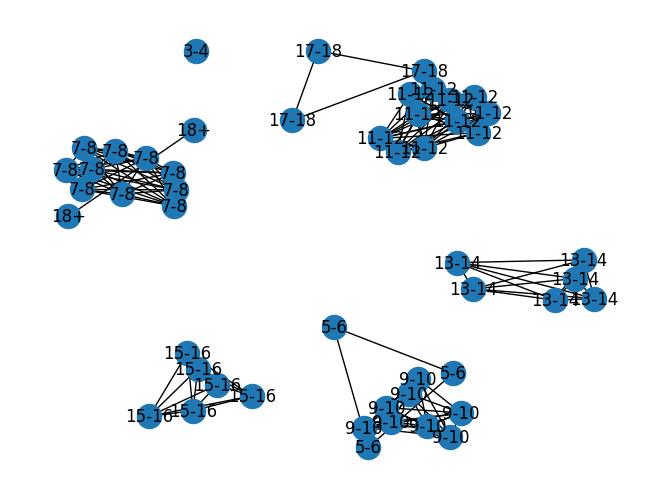

```python
import matplotlib.pyplot as plt
import networkx as nx
import numpy as np

# Create a copy of the 'Customer_Service_Records' dataframe with a subset of customers
subset_data = Customer_Service_Records.head(50).copy()

# Categorize 'Total_Calls' into ranges
# subset_data['Total_Calls_Range'] = pd.cut(subset_data['Total_Calls'], bins=[0, 5, 10, 20, np.inf], labels=['0-5', '6-10', '11-20', '20+'])
subset_data['Total_Calls_Range'] = pd.cut(subset_data['Total_Calls'], bins=[0, 2, 4, 6, 8, 10, 12, 14, 16, 18, np.inf], labels=['0-2', '3-4', '5-6', '7-8', '9-10', '11-12', '13-14', '15-16', '17-18', '18+'])

# Create an empty graph
G = nx.Graph()

# Add nodes to the graph from the 'Customer_ID' column
G.add_nodes_from(subset_data['Customer_ID'])

# Create a dictionary of labels for the nodes
labels = {row['Customer_ID']:row['Total_Calls_Range'] for index, row in subset_data.iterrows()}

# Iterate over the dataframe and add edges between customers who have the same 'Total_Calls_Range'
for i in range(len(subset_data)):
    for j in range(i+1, len(subset_data)):
        if subset_data.iloc[i]['Total_Calls_Range'] == subset_data.iloc[j]['Total_Calls_Range']:
            G.add_edge(subset_data.iloc[i]['Customer_ID'], subset_data.iloc[j]['Customer_ID'])

# Create a layout for the nodes
pos = nx.spring_layout(G, k=0.6)

# Draw the graph using the layout
nx.draw(G, pos, with_labels=False)  # Disable the default labels

# Draw the labels on the graph
nx.draw_networkx_labels(G, pos, labels=labels)

plt.show()
```

In this graph, each node is a customer and an edge between two customers indicates that they made a similar number of calls to the service team. By analyzing this graph, we can identify clusters of customers who have similar behavior in terms of service calls.

Here's how to interpret this graph:

1. **Densely Connected Subgraphs (Clusters):** These groups correspond to customers who share similar behavior, in this case, making a similar number of service calls. Analyzing these clusters can reveal common patterns and characteristics. For example, if a significant number of customers from a high churn risk demographic are found in a cluster with high call volumes, it might indicate dissatisfaction and a potential risk of churn.
2. **Isolated Nodes or Loosely Connected Nodes:** These represent customers whose 'Total_Calls' range is not common among the considered dataset. It does not directly indicate satisfaction or dissatisfaction but shows that their service call behavior is unique compared to the analyzed subset of customers.

## Question 5: Feature Engineering for Churn Prediction

Develop new features such as 'Average_Service_Complaints', 'Payment_Frequency_Change', and 'Usage_Decrease' ratios from the identified churn indicators.

### Solution

**Hints & Explanations**

1. Compute 'Average_Service_Complaints' by dividing 'Total_Complaints' by 'Tenure' from `Customer_Profile`.
2. Merge 'Late_Payments' from `Billing_Data` into `Customer_Service_Records` based on 'Customer_ID'.
3. Create 'Payment_Frequency_Change' feature. Mark it as 'Yes' if 'Late_Payments' is more than 0; otherwise 'No'.
4. Integrate 'Monthly_Charge' and 'Total_Charges' from `Billing_Data` into `Customer_Service_Records` using 'Customer_ID'.
5. Design the 'Usage_Decrease' feature. If 'Total_Charges' is less than ('Monthly_Charge' multiplied by 'Tenure'), label as 'Yes', otherwise 'No'.

```python
# Add 'Average_Service_Complaints'
Customer_Service_Records['Average_Service_Complaints'] = Customer_Service_Records['Total_Complaints'] / Customer_Profile['Tenure']

# Merge 'Late_Payments' into 'Customer_Service_Records'
Customer_Service_Records = pd.merge(Customer_Service_Records, Billing_Data[['Customer_ID', 'Late_Payments']], on='Customer_ID')

# Add 'Payment_Frequency_Change' based on 'Late_Payments'
Customer_Service_Records['Payment_Frequency_Change'] = Customer_Service_Records['Late_Payments'].apply(lambda x: 'Yes' if x > 0 else 'No')

# Merge 'Monthly_Charge' and 'Total_Charges' into 'Customer_Service_Records'
Customer_Service_Records = pd.merge(Customer_Service_Records, Billing_Data[['Customer_ID', 'Monthly_Charge', 'Total_Charges']], on='Customer_ID')

# Add 'Usage_Decrease'
Customer_Service_Records['Usage_Decrease'] = np.where(Customer_Service_Records['Total_Charges'] < (Customer_Service_Records['Monthly_Charge'] * Customer_Profile['Tenure']), 'Yes', 'No')
```

```python
Customer_Service_Records
```

|  | Customer_ID | Total_Calls | Total_Complaints | Resolved_Complaints | Unresolved_Complaints | Average_Service_Complaints | Late_Payments | Payment_Frequency_Change | Monthly_Charge | Total_Charges | Usage_Decrease |
| --- | --- | --- | --- | --- | --- | --- | --- | --- | --- | --- | --- |
| 0 | 1 | 8 | 6 | 4 | 2 | 0.200000 | 2 | Yes | 57.38 | 1721.40 | No |
| 1 | 2 | 10 | 4 | 2 | 2 | 0.285714 | 1 | Yes | 69.06 | 966.84 | No |
| 2 | 3 | 16 | 7 | 4 | 3 | 0.350000 | 3 | Yes | 25.36 | 507.20 | No |
| 3 | 4 | 16 | 6 | 0 | 6 | 0.142857 | 4 | Yes | 44.73 | 1878.66 | No |
| 4 | 5 | 16 | 10 | 2 | 8 | 0.222222 | 3 | Yes | 80.12 | 3605.40 | No |
| ... | ... | ... | ... | ... | ... | ... | ... | ... | ... | ... | ... |
| 995 | 996 | 13 | 3 | 0 | 3 | 0.083333 | 2 | Yes | 20.75 | 747.00 | No |
| 996 | 997 | 13 | 2 | 1 | 1 | 0.071429 | 1 | Yes | 99.12 | 2775.36 | No |
| 997 | 998 | 9 | 6 | 6 | 0 | 1.500000 | 0 | No | 78.37 | 313.48 | No |
| 998 | 999 | 17 | 11 | 2 | 9 | 1.375000 | 4 | Yes | 32.37 | 258.96 | No |
| 999 | 1000 | 4 | 7 | 1 | 6 | 1.400000 | 1 | Yes | 97.73 | 488.65 | Yes |

1000 rows × 11 columns

Now we have a new dataframe, `Customer_Service_Records`, augmented with the features 'Average_Service_Complaints', 'Payment_Frequency_Change', and 'Usage_Decrease'.

When building a predictive model for churn, these new features could enhance the model's performance by providing more nuanced information about customer behavior.

1. **Average_Service_Complaints:** This feature gives an average rate of service complaints per month. Higher values may signal customer dissatisfaction, increasing the likelihood of churn.
2. **Payment_Frequency_Change:** Customers who frequently change their payment method or have late payments might be considered financially unstable or unsatisfied, which could increase the risk of churn.
3. **Usage_Decrease:** If customers are paying for services they're not fully utilizing, they might perceive a lack of value, increasing their likelihood to churn.

## Question 6: Development and Optimization of Churn Prediction Model

Implement a predictive model in Python using these features and elaborate on how this model will steer proactive customer retention strategies.

### Solution

**Hints & Explanations**

1. **Data Integration**:
   - Merge relevant datasets using 'Customer_ID'.
2. **Data Preprocessing**:
   - Convert categorical variables to dummy variables and split into training and test sets.
3. **Handling Data Imbalance**:
   - Apply RandomUnderSampler and SMOTE to balance the dataset.
4. **Model Setup & Tuning**:
   - Define hyperparameters for RandomForestClassifier.
   - Implement GridSearchCV for hyperparameter optimization.
5. **Training & Evaluation**:
   - Train with both undersampled and oversampled data.
   - Predict on test data and evaluate performance.
6. **Feature Importance**:
   - Visualize significant features affecting customer churn.

```
Tuned Random Forest Parameters with undersampling: {'max_depth': None, 'min_samples_leaf': 1, 'min_samples_split': 5, 'n_estimators': 100}
Best score with undersampling is 0.8454545454545455
              precision    recall  f1-score   support

           0       0.96      0.92      0.94       159
           1       0.73      0.85      0.79        41

    accuracy                           0.91       200
   macro avg       0.84      0.89      0.86       200
weighted avg       0.91      0.91      0.91       200
```

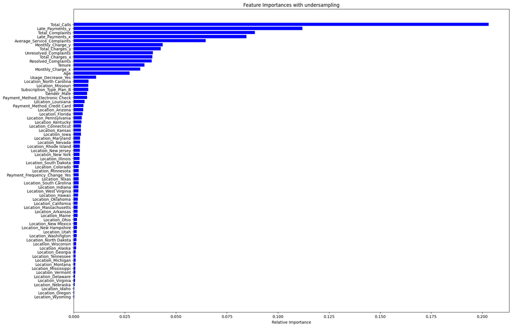

```
Tuned Random Forest Parameters with oversampling: {'max_depth': None, 'min_samples_leaf': 1, 'min_samples_split': 2, 'n_estimators': 200}
Best score with oversampling is 0.9307086614173228
              precision    recall  f1-score   support

           0       0.96      0.94      0.95       159
           1       0.79      0.83      0.81        41

    accuracy                           0.92       200
   macro avg       0.87      0.89      0.88       200
weighted avg       0.92      0.92      0.92       200
```

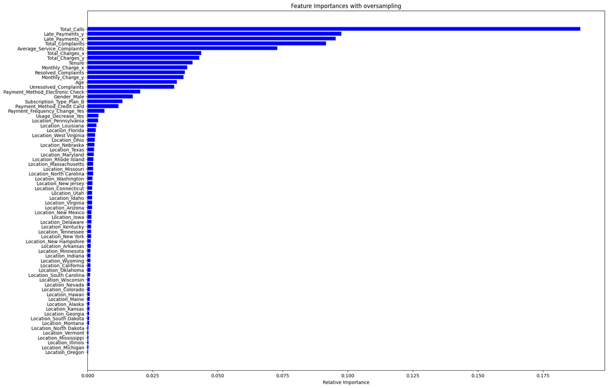

```python
from sklearn.ensemble import RandomForestClassifier
from sklearn.metrics import classification_report, confusion_matrix
from sklearn.model_selection import GridSearchCV
from sklearn.model_selection import train_test_split
from imblearn.under_sampling import RandomUnderSampler
from imblearn.over_sampling import SMOTE
import matplotlib.pyplot as plt
import numpy as np
import pandas as pd

# Merging all datasets together on 'Customer_ID'
data = pd.merge(Customer_Profile, Billing_Data, on='Customer_ID')
data = pd.merge(data, Customer_Service_Records, on='Customer_ID')

# Convert 'Churn' into a binary variable
data['Churn'] = data['Churn'].map({'Yes': 1, 'No': 0})

# Converting other categorical variables into dummy variables
data = pd.get_dummies(data, columns=['Gender', 'Location', 'Subscription_Type', 'Payment_Method', 'Payment_Frequency_Change', 'Usage_Decrease'], drop_first=True)

# Split the data into features and target variable
X = data.drop(['Customer_ID', 'Churn'], axis=1)
y = data['Churn']

# Splitting the data into training and test sets
X_train, X_test, y_train, y_test = train_test_split(X, y, test_size=0.2, random_state=42)

# Apply RandomUnderSampler
rus = RandomUnderSampler(random_state=2)
X_train_rus, y_train_rus = rus.fit_resample(X_train, y_train)

# Apply SMOTE
sm = SMOTE(random_state=2)
X_train_ros, y_train_ros = sm.fit_resample(X_train, y_train)

# Set up hyperparameter grid for tuning
param_grid = {
    'n_estimators': [100, 200, 300],
    'max_depth': [None, 5, 10],
    'min_samples_split': [2, 5, 10],
    'min_samples_leaf': [1, 3, 5]
}

# Instantiate a RandomForestClassifier
rf = RandomForestClassifier(class_weight={0: 0.8, 1: 0.2})

# Instantiate the GridSearchCV object
rf_cv = GridSearchCV(rf, param_grid, cv=5)

# Fit it to the undersampled data
rf_cv.fit(X_train_rus, y_train_rus)

# Print the tuned parameters and score for undersampled data
print("Tuned Random Forest Parameters with undersampling: {}".format(rf_cv.best_params_))
print("Best score with undersampling is {}".format(rf_cv.best_score_))

# Predict the labels of the test set for undersampled data
y_pred_rus = rf_cv.predict(X_test)

# Generate the classification report for undersampled data
print(classification_report(y_test, y_pred_rus, zero_division=1))

# Show feature importances for undersampled data
importances_rus = rf_cv.best_estimator_.feature_importances_
features = X.columns
indices_rus = np.argsort(importances_rus)

plt.figure(figsize=(20,14))
plt.title('Feature Importances with undersampling')
plt.barh(range(len(indices_rus)), importances_rus[indices_rus], color='b', align='center')
plt.yticks(range(len(indices_rus)), [features[i] for i in indices_rus])
plt.xlabel('Relative Importance')
plt.show()

# Fit it to the oversampled data
rf_cv.fit(X_train_ros, y_train_ros)

# Print the tuned parameters
print("Tuned Random Forest Parameters with oversampling: {}".format(rf_cv.best_params_))
print("Best score with oversampling is {}".format(rf_cv.best_score_))

# Predict the labels of the test set for oversampled data
y_pred_ros = rf_cv.predict(X_test)

# Generate the classification report for oversampled data
print(classification_report(y_test, y_pred_ros, zero_division=1))

# Show feature importances for oversampled data
importances_ros = rf_cv.best_estimator_.feature_importances_
indices_ros = np.argsort(importances_ros)

plt.figure(figsize=(20,14))
plt.title('Feature Importances with oversampling')
plt.barh(range(len(indices_ros)), importances_ros[indices_ros], color='b', align='center')
plt.yticks(range(len(indices_ros)), [features[i] for i in indices_ros])
plt.xlabel('Relative Importance')
plt.show()
```

From the results, you can see that over-sampling with SMOTE produced a model with better overall accuracy, precision, and F1-score on the test set than the under-sampling method. However, it is important to note that the recall for the churned customers (1) was higher in the model trained on the under-sampled data, which might be significant if correctly identifying churned customers is the main priority.

The choice between these two models depends on the specific business context. If it's more important to catch as many churned customers as possible (potentially at the cost of misclassifying some non-churned customers as churned), the model trained with under-sampling might be preferable. However, if overall performance on all metrics is the main goal, the model trained with over-sampling appears to perform better.